# Okesola Moses Olusola EasyVisa Project

**Checking model performance on testing set**

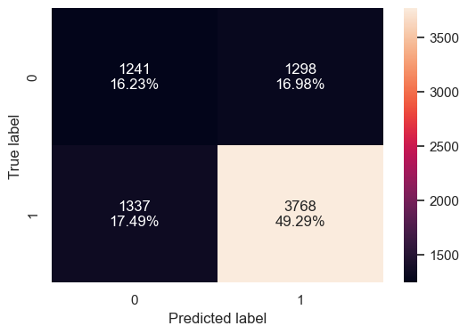

```python
confusion_matrix_sklearn(dtree, X_test, y_test)
```

- True Positives (TP) and True Negatives (TN):

The confusion matrix shows 3768 true positives (actual visa approvals predicted as approved) and 1241 true negatives (actual visa denials predicted as denied)

False Positives (FP) and False NegativesF):

The model predicted 1298 visa denials as approvals (false positives) and 1337 visa approvals as denials (false negatives).

```python
# Check performance on the test data
decision_tree_perf_test = model_performance_classification_sklearn(X_test, y_test, dtree)

print("Decision Tree Model Performance on Testing Data:")
print(decision_tree_perf_test)
```

```
Accuracy: 0.6552851909994767
Precision: 0.7437820765890248
Recall: 0.7380999020568071
F1-score: 0.740930095369187
Decision Tree Model Performance on Testing Data:
{'Accuracy': 0.6552851909994767, 'Precision': 0.7437820765890248, 'Recall': 0.7380999020568071, 'F1-score': 0.740930095369187}
```

- The comparison between training and testing data performance metrics reveals a significant drop in values on the testing data, indicating that the model has not generalized well from the training data to unseen data.
- The perfect scores (1.0) on the training data for accuracy, precision, recall, and F1-score suggest that the model memorized the training data, leading to potential overfiting.

The lower accuracy, precision, recall, and F1-score values on the testing data compared to the training data highlight the discrepancy in model performance between seen and unseendata.

**Hyperparameter Tuning - Decision Tree Classifier**

- Sample parameter grids have been provided to do necessary hyperparameter tuning. These sample grids are expected to provide a balance between model performance improvement and execution time. One can extend/reduce the parameter grid based on execution time and system configuration.
- Note that if the parameter grid is extended to improve the model performance further, the execution time will increase.

The models chosen in this notebook are based on test runs. One can update the best models as obtained upon code execution and tune them for best performance.

```python
# Choose the type of classifier
dtree_tuned = DecisionTreeClassifier(class_weight="balanced", random_state=1)

# Grid of parameters to choose from
parameters = {
    'max_depth': np.arange(2,6),
    'min_samples_leaf': [1, 4, 7],
    'max_leaf_nodes' : [10, 15],
    'min_impurity_decrease': [0.0001,0.001]
}

# Type of scoring used to compare parameter combinations
scorer = metrics.make_scorer(metrics.f1_score)

# Run the grid search
grid_obj = GridSearchCV(dtree_tuned, parameters, scoring=scorer, n_jobs=-1)
grid_obj = grid_obj.fit(X_train, y_train)

# Set the dtree_tuned to the best combination of parameters
dtree_tuned = grid_obj.best_estimator_

# Fit the best algorithm to the data
dtree_tuned.fit(X_train, y_train)
```

```
DecisionTreeClassifier(class_weight='balanced', max_depth=5, max_leaf_nodes=10,
                       min_impurity_decrease=0.0001, random_state=1)
```

**Checking performance on training set**

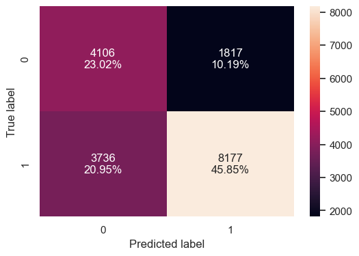

```python
confusion_matrix_sklearn(dtree_tuned, X_train, y_train) ## create confusion matrix for train data
```

- True Positives (Actual 1, Predicted 1):

The bottom-right cell with a value of 8177 represents the number of true positives. This indicates that the model correctly predicted 8177 cases where the visa was actually approved (1) as approved (1)

```python
# Check performance on the training data
decision_tree_tune_perf_train = model_performance_classification_sklearn(X_train, y_train, dtree_tuned)

print("Decision Tree Tune Model Performance on Training Data:")
print(decision_tree_tune_perf_train)
```

```
Accuracy: 0.6886633774388876
Precision: 0.8181909145487293
Recall: 0.6863930160329053
F1-score: 0.7465193773679646
Decision Tree Tune Model Performance on Training Data:
{'Accuracy': 0.6886633774388876, 'Precision': 0.8181909145487293, 'Recall': 0.6863930160329053, 'F1-score': 0.7465193773679646}
```

**Checking performance on testing set**

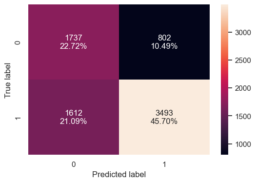

```python
confusion_matrix_sklearn(dtree_tuned, X_test, y_test) ## create confusion matrix for test data
```

- True Positives and True Negatives:

The confusion matrix indicates that there are 3493 true positives (actual visa approvals predicted as approved) and 1737 true negatives (actual visa denials predicted as denied).

The model predicted 802 visa denials as approvals (false positives) and 1612 visa approvals as denials (false negatives).

```python
# Check performance on the test data
decision_tree_tune_perf_test = model_performance_classification_sklearn(X_test, y_test, dtree_tuned)

print("Decision Tree Tune Model Performance on Testing Data:")
print(decision_tree_tune_perf_test)
```

```
Accuracy: 0.684196755625327
Precision: 0.8132712456344586
Recall: 0.6842311459353575
F1-score: 0.7431914893617022
Decision Tree Tune Model Performance on Testing Data:
{'Accuracy': 0.684196755625327, 'Precision': 0.8132712456344586, 'Recall': 0.6842311459353575, 'F1-score': 0.7431914893617022}
```

- Consistency between Training and Testing:

The Decision Tree model retains similar performance levels between the training and testing datasets, with minimal variance in accuracy, precision, recall, and F1-score.

- The stable performance metrics reflect the model's reliability and effectiveness in accurately predicting visa outcomes with consistent precision, recall, and F1-score values.

decision_tree_tune_perf_test = model_performance_classification_sklearn(y_test, dtree_tuned.predict(X_test)) ## the code to check performance on test data # Separate and arrange the output for better readability accuracy, report = decision_tree_tune_perf_train print("Decision Tree Tune Model Performance on Testing Data:") print("Accuracy:", accuracy) print("\nClassification Report:\n", report)

**Plotting the feature importance of each variable**

```python
# importance of features in the tree building ( The importance of a feature is computed as the
#(normalized) total reduction of the criterion brought by that feature. It is also known as the Gini importance )

print(pd.DataFrame(dtree_tuned.feature_importances_, columns = ["Imp"], index = X_train.columns).sort_values(by = 'Imp', ascending = False))
```

```
                                    Imp
education_of_employee          0.372206
education_of_employee_encoded  0.221628
has_job_experience             0.185183
unit_of_wage                   0.129331
has_job_experience_encoded     0.056494
continent                      0.021370
region_of_employment           0.013789
requires_job_training_encoded  0.000000
region_of_employment_encoded   0.000000
unit_of_wage_encoded           0.000000
full_time_position_encoded     0.000000
full_time_position             0.000000
continent_encoded              0.000000
prevailing_wage                0.000000
no_of_employees                0.000000
requires_job_training          0.000000
age_of_company                 0.000000
```

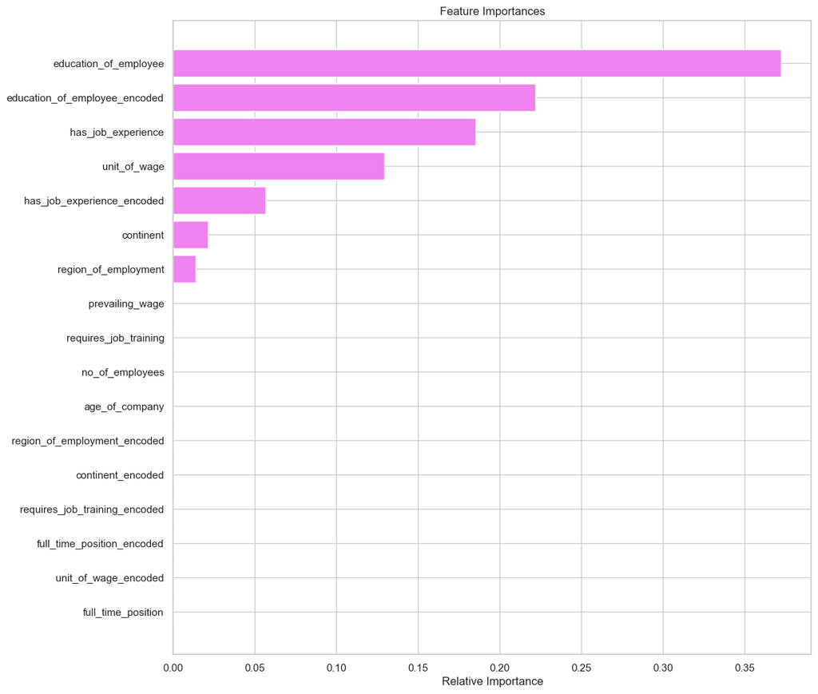

```python
feature_names = X_train.columns
importances = dtree_tuned.feature_importances_
indices = np.argsort(importances)

plt.figure(figsize=(12,12))
plt.title('Feature Importances')
plt.barh(range(len(indices)), importances[indices], color='violet', align='center')
plt.yticks(range(len(indices)), [feature_names[i] for i in indices])
plt.xlabel('Relative Importance')
plt.show()
```

- education_of_employee, has_job_experience, unit_of_wage, continent, and region_of_employment are in decreasing order of their importance as captured by tuned decision tree model in determining whether or not visa application will be approved for the employees.
- The relative importance of encoded features are ignored because they cannot influence our prediction.

**Bagging Classifier**

```python
bagging = BaggingClassifier(random_state=1)
bagging.fit(X_train,y_train)
```

```
BaggingClassifier(random_state=1)
```

**Checking performance on Training set**

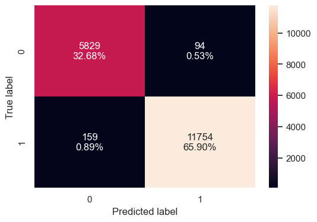

```python
confusion_matrix_sklearn(bagging, X_train, y_train)
```

- True Positives (TP) and True Negatives (TN):TThe confusion matrix indicates 11754 true positives (actual visa approvals predicted as approved) and 5829 true negatives (actual visa denials predicted as denied.

False Positives (FP) and False Negatives)

The model predicted 94 visa denials as approvals (false positives) and 159 visa approvals as denials (false negatives).

```python
# Check performance on the train data
bagging_model_perf_train = model_performance_classification_sklearn(X_train, y_train, bagging)

print("Bagging Model Performance on Training Data:")
print(bagging_model_perf_train)
```

```
Accuracy: 0.9858152052029603
Precision: 0.9920661715057394
Recall: 0.9866532359607152
F1-score: 0.9893522999873743
Bagging Model Performance on Training Data:
{'Accuracy': 0.9858152052029603, 'Precision': 0.9920661715057394, 'Recall': 0.9866532359607152, 'F1-score': 0.9893522999873743}
```

bagging_model_train_perf=model_performance_classification_sklearn( y_train, bagging.predict(X_train)) print("Training performance:\nAccuracy:", bagging_model_train_perf[0]) print("Classification Report:\n", bagging_model_train_perf[1])

**Checking performance on Testing set**

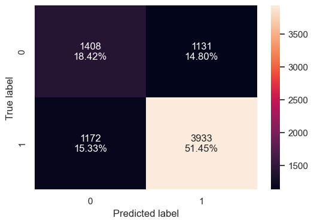

```python
confusion_matrix_sklearn(bagging, X_test, y_test)
```

- True Positives (TP) and True Negatives (TN):The confusion matrix shows 3933 true positives (actual visa approvals predicted as approved) and 1408 true negatives (actual visa denials predicted as denied).
- False Positives (FP) and False Negatives (FN):The model predicted 1131 visa denials as approvals (false positives) and 1172 visa approvals as denials (false negatives).

```python
# Check performance on the test data
bagging_model_perf_test = model_performance_classification_sklearn(X_test, y_test, bagging)

print("Bagging Model Performance on Testing Data:")
print(bagging_model_perf_test)
```

```
Accuracy: 0.6987179487179487
Precision: 0.7766587677725119
Recall: 0.7704211557296767
F1-score: 0.7735273871570459
Bagging Model Performance on Testing Data:
{'Accuracy': 0.6987179487179487, 'Precision': 0.7766587677725119, 'Recall': 0.7704211557296767, 'F1-score': 0.7735273871570459}
```

- Training vs. Testing Comparison:

The Bagging model demonstrates significantly higher performance on the training data compared to the testing data, with a noticeable drop in accuracy, precision, recall, and F1-score from the training to the testing dataset.

- The significant disparity in performance metrics between training and testing data highlights potential overfitting of the Bagging model to the training dataset, resulting in reduced generalization capabilities on new and unseen data.

bagging_model_test_perf=model_performance_classification_sklearn(y_test, bagging.predict(X_test)) # Separate and arrange the output for better readability test_accuracy, test_report = bagging_model_test_perf print("Bagging Model Performance on Testing Data:") print("Testing Accuracy:", test_accuracy) print("\nClassification Report for Testing Data:\n", test_report)

**Bagging Classifier with weighted decision tree**

```python
bagging_wt = BaggingClassifier(base_estimator=DecisionTreeClassifier(criterion='gini',class_weight={0:0.17,1:0.83},random_state=1),random_state=1)
bagging_wt.fit(X_train,y_train)
```

```
BaggingClassifier(base_estimator=DecisionTreeClassifier(class_weight={0: 0.17,
                                                                      1: 0.83},
                                                        random_state=1),
                  random_state=1)
```

**Checking performance on Training set**

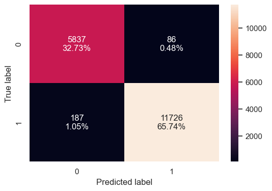

```python
confusion_matrix_sklearn(bagging_wt,X_train,y_train)
```

- True Positives (TP) and True Negatives (TN):

The confusion matrix shows 11726 true positives (actual visa approvals predicted as approved) and 5837 true negatives (actual visa denials predicted as denied).

False Positives (FP) and False Negatives)

The model predicted 86 visa denials as approvals (false positives) and 187 visa approvals as denials (false negatives).

```python
# Check performance on the train data
bagging_wt_model_perf_train = model_performance_classification_sklearn(X_train, y_train, bagging_wt)

print("Bagging-Weight Model Performance on Training Data:")
print(bagging_wt_model_perf_train)
```

```
Accuracy: 0.9846938775510204
Precision: 0.9927192685404673
Recall: 0.984302862419206
F1-score: 0.9884931506849316
Bagging-Weight Model Performance on Training Data:
{'Accuracy': 0.9846938775510204, 'Precision': 0.9927192685404673, 'Recall': 0.984302862419206, 'F1-score': 0.9884931506849316}
```

bagging_wt_model_train_perf=model_performance_classification_sklearn(y_train,bagging_wt.predict(X_train)) train_accuracy, train_report = bagging_wt_model_train_perf print("Bagging with Weighted Samples Model Performance on Training Data:") print("Training Accuracy:", train_accuracy) print("\nClassification Report for Training Data:\n", train_report)

**Checking performance on Testing set**

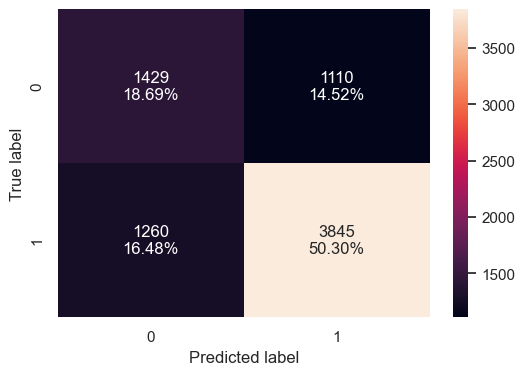

```python
confusion_matrix_sklearn(bagging_wt,X_test,y_test)
```

- True Positives and True Negatives:

The confusion matrix indicates that there are 3845 true positives (actual visa approvals predicted as approved) and 1429 true negatives (actual visa denials predicted as denied)

False Positives and False Negas:

The model predicted 1110 visa denials as approvals (false positives) and 1260 visa approvals as denials (false negatives).

```python
# Check performance on the test data
bagging_wt_model_perf_test = model_performance_classification_sklearn(X_test, y_test, bagging_wt)

print("Bagging-Weight Model Performance on Testing Data:")
print(bagging_wt_model_perf_test)
```

```
Accuracy: 0.6899529042386185
Precision: 0.7759838546922301
Recall: 0.7531831537708129
F1-score: 0.76441351888668
Bagging-Weight Model Performance on Testing Data:
{'Accuracy': 0.6899529042386185, 'Precision': 0.7759838546922301, 'Recall': 0.7531831537708129, 'F1-score': 0.76441351888668}
```

- Training vs. Testing Comparison:

The Bagging-Weight model exhibits higher performance on the training data in terms of accuracy, precision, recall, and F1-score compared to the testing data. There is a noticeable drop in performance metrics when transitioning from the training to the testing datast.

- The significant drop in performance metrics from training to testing data highlights the model's potential overfitting to the training dataset, necessitating measures to enhance generalization capabilities for robust predictions on new instances.

**Hyperparameter Tuning - Bagging Classifier**

```python
# Choose the type of classifier
bagging_tuned = BaggingClassifier(random_state=1)

# Grid of parameters to choose from
parameters = {
    'max_samples': [0.8,0.9,1],
    'max_features': [0.7,0.8,0.9],
    'n_estimators' : [30,50,70],
}

# Type of scoring used to compare parameter combinations
acc_scorer = metrics.make_scorer(metrics.f1_score)

# Run the grid search
grid_obj = GridSearchCV(bagging_tuned, parameters, scoring=acc_scorer, cv=5)
grid_obj = grid_obj.fit(X_train, y_train)

# Set the bagging_tuned to the best combination of parameters
bagging_tuned = grid_obj.best_estimator_

# Fit the best algorithm to the data
bagging_tuned.fit(X_train, y_train)
```

```
BaggingClassifier(max_features=0.7, max_samples=0.8, n_estimators=70,
                  random_state=1)
```

**Checking the performance on training set**

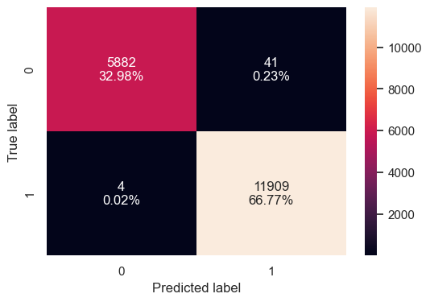

```python
confusion_matrix_sklearn(bagging_tuned, X_train,y_train)
```

- True Positives (TP) and True Negatives (TN):

The confusion matrix indicates that there are 11909 true positives (actual visa approvals predicted as approved) and 5882 true negatives (actual visa denials predicted as denied).

False Positives (FP) and False Negatives)

The model predicted 41 visa denials as approvals (false positives) and 4 visa approvals as denials (false negatives).

```python
# Check performance on the train data
bagging_tune_model_perf_train = model_performance_classification_sklearn(X_train, y_train, bagging_tuned)

print("Bagging Tune Model Performance on Training Data:")
print(bagging_tune_model_perf_train)
```

```
Accuracy: 0.9974770127831353
Precision: 0.9965690376569037
Recall: 0.9996642323512129
F1-score: 0.9981142354272304
Bagging Tune Model Performance on Training Data:
{'Accuracy': 0.9974770127831353, 'Precision': 0.9965690376569037, 'Recall': 0.9996642323512129, 'F1-score': 0.9981142354272304}
```

bagging_tune_model_train_perf=model_performance_classification_sklearn(y_train,bagging_tuned.predict(X_train)) train_accuracy, train_report = bagging_tune_model_train_perf print("Bagging with Weighted Samples Model Performance on Training Data:") print("Training Accuracy:", train_accuracy) print("\nClassification Report for Training Data:\n", train_report)

**Checking the performance on testing set**

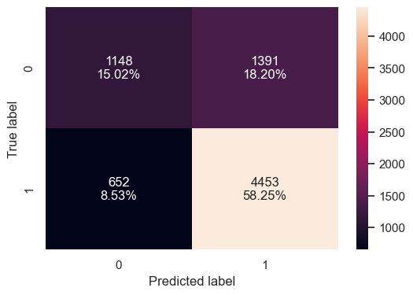

```python
confusion_matrix_sklearn(bagging_tuned, X_test,y_test)
```

- True Positives (TP) and True Negatives (TN):

The confusion matrix indicates there are 4453 true positives (actual visa approvals predicted as approved) and 1148 true negatives (actual visa denials predicted as denied).

False Positives (FP) and False Negatives)

The model predicted 1391 visa denials as approvals (false positives) and 652 visa approvals as denials (false negatives).

```python
# Check performance on the test data
bagging_tune_model_perf_test = model_performance_classification_sklearn(X_test, y_test, bagging_tuned)

print("Bagging Tune Model Performance on Testing Data:")
print(bagging_tune_model_perf_test)
```

```
Accuracy: 0.7327315541601256
Precision: 0.7619780971937029
Recall: 0.8722820763956906
F1-score: 0.8134076171339848
Bagging Tune Model Performance on Testing Data:
{'Accuracy': 0.7327315541601256, 'Precision': 0.7619780971937029, 'Recall': 0.8722820763956906, 'F1-score': 0.8134076171339848}
```

- Training vs. Testing Comparison:

- The significant drop in performance metrics from training to testing data underscores the model's potential overfitting to the training dataset, calling for measures to enhance generalization capabilities for robust predictions on new instances.

**Plotting the feature importance of each variable**

```python
# Calculate feature importances manually by averaging the feature importances from base estimators
importances = np.mean([estimator.feature_importances_ for estimator in bagging_tuned.estimators_], axis=0)

# Correcting the DataFrame creation to align with the shape of the passed values and the indices
importances_df = pd.DataFrame(importances.reshape(-1, 1), columns=["Imp"], index=X_train.columns[:len(importances)])
importances_df = importances_df.sort_values(by='Imp', ascending=False)

print(importances_df)
```

```
                                    Imp
continent                      0.128854
full_time_position             0.118575
prevailing_wage                0.096632
requires_job_training          0.094393
education_of_employee          0.092647
no_of_employees                0.087975
unit_of_wage                   0.083565
region_of_employment           0.076062
continent_encoded              0.075713
education_of_employee_encoded  0.075548
has_job_experience             0.070036
```

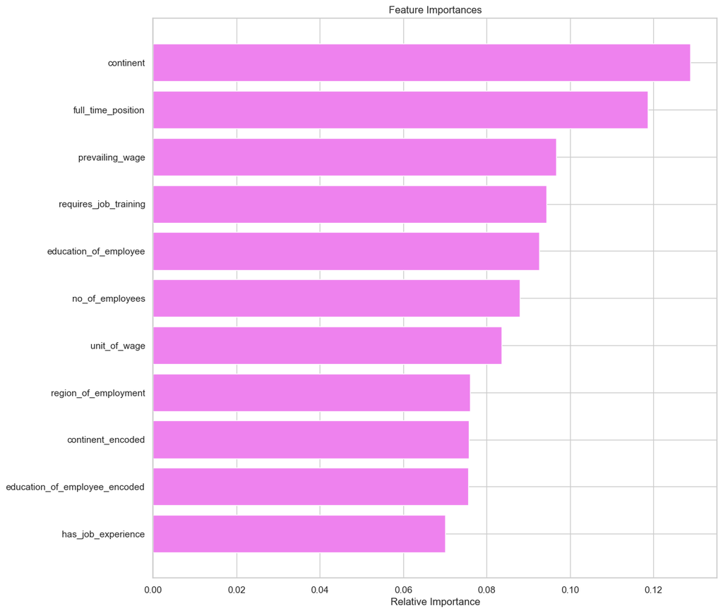

```python
# Calculate the mean feature importances across all trees in the BaggingClassifier
feature_names = X_train.columns
importances = np.mean([tree.feature_importances_ for tree in bagging_tuned.estimators_], axis=0)
indices = np.argsort(importances)

plt.figure(figsize=(12, 12))
plt.title('Feature Importances')
plt.barh(range(len(indices)), importances[indices], color='violet', align='center')
plt.yticks(range(len(indices)), [feature_names[i] for i in indices])
plt.xlabel('Relative Importance')
plt.show()
```

- The relative importance of encoded features are ignored because they cannot influence our prediction.

**Random Forest Classifier**

```python
rf = RandomForestClassifier(random_state=1)
rf.fit(X_train,y_train)
```

```
RandomForestClassifier(random_state=1)
```

**Checking performance on Training set**

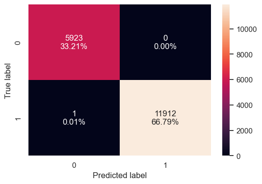

```python
confusion_matrix_sklearn(rf,X_train,y_train)
```

- True Positives (TP) and True Negatives (TN):

The confusion matrix indicates there are 11912 true positives (actual visa approvals predicted as approved) and 5923 true negatives (actual visa denials predicted as denied).

The model correctly predicted all instances of visa denials (0 denials predicted as approvals), and there was 1 visa approval misclassified as a denial.

```python
# Check performance on the train data
rf_model_perf_train = model_performance_classification_sklearn(X_train, y_train, rf)

print("Random Forest Model Performance on Training Data:")
print(rf_model_perf_train)
```

```
Accuracy: 0.999943933617403
Precision: 1.0
Recall: 0.9999160580878033
F1-score: 0.9999580272822666
Random Forest Model Performance on Training Data:
{'Accuracy': 0.999943933617403, 'Precision': 1.0, 'Recall': 0.9999160580878033, 'F1-score': 0.9999580272822666}
```

**Checking performance on Testing set**

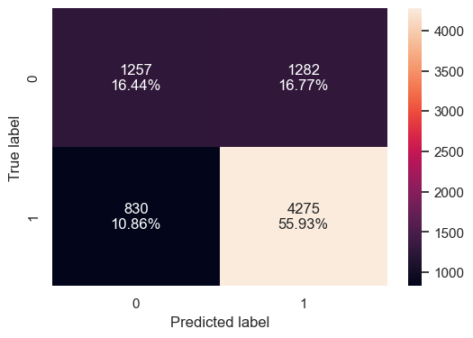

```python
confusion_matrix_sklearn(rf,X_test,y_test)
```

- True Positives (TP) and True Negatives (TN):TThe confusion matrix reveals there are 4275 true positives (actual visa approvals predicted as approved) and 1257 true negatives (actual visa denials predicted as denied).

False Positives (FP) and False Negatives)

The model predicted 1282 visa denials as approvals (false positives) and 830 visa approvals as denials (false negatives).

```python
# Check performance on the test data
rf_model_perf_test = model_performance_classification_sklearn(X_test, y_test, rf)

print("Random Forest Model Performance on Testing Data:")
print(rf_model_perf_test)
```

```
Accuracy: 0.7237048665620094
Precision: 0.7692999820046788
Recall: 0.8374142997061704
F1-score: 0.8019133370849747
Random Forest Model Performance on Testing Data:
{'Accuracy': 0.7237048665620094, 'Precision': 0.7692999820046788, 'Recall': 0.8374142997061704, 'F1-score': 0.8019133370849747}
```

- Training vs. Testing Comparison:

The Random Forest model demonstrates exceptional performance on the training data in terms of accuracy, precision, recall, and F1-score, with all values close to or equal to 1.0. However, there is a noticeable drop in performance metrics on the testing data.

- The substantial drop in performance metrics from training to testing data highlights the model's potential overfitting to the training dataset, necessitating measures to improve generalization for robust predictions on new instances.

**Random forest with class weights**

```python
rf_wt = RandomForestClassifier(class_weight={0:0.17,1:0.83}, random_state=1)
rf_wt.fit(X_train,y_train)
```

```
RandomForestClassifier(class_weight={0: 0.17, 1: 0.83}, random_state=1)
```

**Checking performance on Training set**

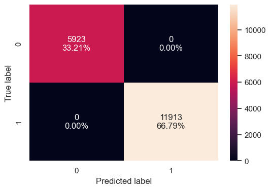

```python
confusion_matrix_sklearn(rf_wt, X_train,y_train)
```

- True Positives (TP) and True Negatives (TN):

The model correctly predicted all instances of visa denials (5923 denials predicted as denied) and all instances of visa approvals (11913 approvals predicted as approved).

False Positives (FP) and False Negatives)

There were no instances where visa denials were falsely predicted as approvals (false positives) and no visa approvals falsely predicted as denials (false negatives).

```python
# Check performance on the train data
rf_wt_model_perf_train = model_performance_classification_sklearn(X_train, y_train, rf_wt)

print("Random Forest-Weight Model Performance on Training Data:")
print(rf_wt_model_perf_train)
```

```
Accuracy: 1.0
Precision: 1.0
Recall: 1.0
F1-score: 1.0
Random Forest-Weight Model Performance on Training Data:
{'Accuracy': 1.0, 'Precision': 1.0, 'Recall': 1.0, 'F1-score': 1.0}
```

**Checking performance on Testing set**

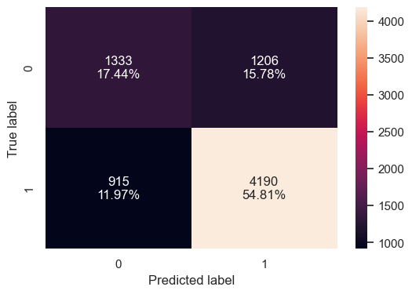

```python
confusion_matrix_sklearn(rf_wt, X_test,y_test)
```

- True Positives (TP) and True Negatives (TN):

The confusion matrix indicates there are 4190 true positives (actual visa approvals predicted as approved) and 1333 true negatives (actual visa denials predicted as denied).

False Positives (FP) and False Negatives)

The model predicted 1206 visa denials as approvals (false positives) and 915 visa approvals as denials (false negatives).

```python
# Check performance on the test data
rf_wt_model_perf_test = model_performance_classification_sklearn(X_test, y_test, rf_wt)

print("Random Forest-Weight Model Performance on Testing Data:")
print(rf_wt_model_perf_test)
```

```
Accuracy: 0.7225274725274725
Precision: 0.7765011119347665
Recall: 0.8207639569049952
F1-score: 0.7980192362632129
Random Forest-Weight Model Performance on Testing Data:
{'Accuracy': 0.7225274725274725, 'Precision': 0.7765011119347665, 'Recall': 0.8207639569049952, 'F1-score': 0.7980192362632129}
```

- Training vs. Testing Comparison:

The Random Forest-Weight model displays perfect performance metrics (accuracy, precision, recall, and F1-score) on the training data. However, there is a noticeable drop in performance when evaluated on the testing data.

- The drop in performance metrics from training to testing data suggests potential overfitting to the training data and highlights the need to enhance the model's generalization capabilities.

**Hyperparameter Tuning - Random Forest**

```python
# Choose the type of classifier.
rf_tuned = RandomForestClassifier(random_state=1)

# Grid of parameters to choose from
parameters= {
    "n_estimators": [50,110,25],
    "min_samples_leaf": np.arange(1, 4),
    "max_features": [np.arange(0.3, 0.6, 0.1),'sqrt'],
    "max_samples": np.arange(0.4, 0.7, 0.1)
}

# Run the grid search
grid_obj = GridSearchCV(rf_tuned, parameters, scoring='recall',cv=5)
grid_obj = grid_obj.fit(X_train, y_train)

# Set the clf to the best combination of parameters
rf_tuned = grid_obj.best_estimator_

# Fit the best algorithm to the data.
rf_tuned.fit(X_train, y_train)
```

```
RandomForestClassifier(max_samples=0.4, min_samples_leaf=3, n_estimators=25,
                       random_state=1)
```

**Checking the performance on training set**

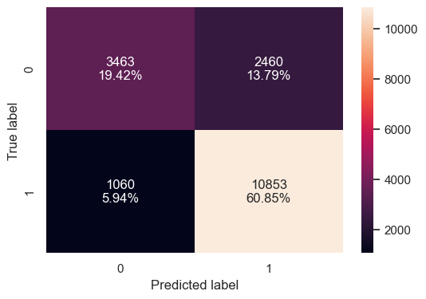

```python
confusion_matrix_sklearn(rf_tuned, X_train,y_train)
```

- True Positives (TP) and True Negatives (TN):

The confusion matrix indicates there are 10853 true positives (actual visa approvals predicted as approved) and 3463 true negatives (actual visa denials predicted as denied).

False Positives (FP) and False Negatives)

The model predicted 2460 visa denials as approvals (false positives) and 1060 visa approvals as denials (false negatives).

```python
# Check performance on the train data
rf_tune_model_perf_train = model_performance_classification_sklearn(X_train, y_train, rf_tuned)

print("Random Forest Tune Model Performance on Training Data:")
print(rf_tune_model_perf_train)
```

```
Accuracy: 0.8026463332585781
Precision: 0.8152182077668444
Recall: 0.9110215730714346
F1-score: 0.8604614286846903
Random Forest Tune Model Performance on Training Data:
{'Accuracy': 0.8026463332585781, 'Precision': 0.8152182077668444, 'Recall': 0.9110215730714346, 'F1-score': 0.8604614286846903}
```

**Checking the performance on testing set**

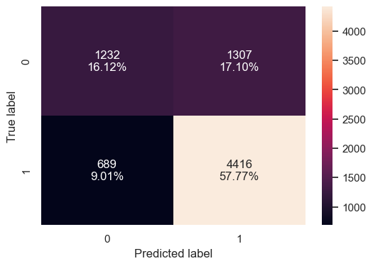

```python
confusion_matrix_sklearn(rf_tuned, X_test,y_test)
```

- True Positives (TP) and True Negatives (TN):

The confusion matrix indicates there are 4416 true positives (actual visa approvals predicted as approved) and 1232 true negatives (actual visa denials predicted as denied)

False Positives (FP) and False Negatives)

The model predicted 1307 visa denials as approvals (false positives) and 689 visa approvals as denials (false negatives).

```python
# Check performance on the test data
rf_tune_model_perf_test = model_performance_classification_sklearn(X_test, y_test, rf_tuned)

print("Random Forest Tune Model Performance on Testing Data:")
print(rf_tune_model_perf_test)
```

```
Accuracy: 0.738880167451596
Precision: 0.7716232745063778
Recall: 0.8650342801175318
F1-score: 0.8156630956778722
Random Forest Tune Model Performance on Testing Data:
{'Accuracy': 0.738880167451596, 'Precision': 0.7716232745063778, 'Recall': 0.8650342801175318, 'F1-score': 0.8156630956778722}
```

- Training vs. Testing Comparison:

- The drop in performance metrics from training to testing data suggests potential challenges with overfitting and highlights the need to enhance the model's generalization capacity.

**Plotting the feature importance of each variable**

```python
# importance of features in the tree building ( The importance of a feature is computed as the
#(normalized) total reduction of the criterion brought by that feature. It is also known as the Gini importance )

print(pd.DataFrame(rf_tuned.feature_importances_, columns = ["Imp"], index = X_train.columns).sort_values(by = 'Imp', ascending = False))
```

```
                                    Imp
prevailing_wage                0.197844
no_of_employees                0.167717
age_of_company                 0.141875
education_of_employee          0.111497
education_of_employee_encoded  0.099559
region_of_employment           0.062940
unit_of_wage                   0.046178
has_job_experience             0.037234
continent_encoded              0.035322
has_job_experience_encoded     0.033087
continent                      0.032029
full_time_position             0.008826
full_time_position_encoded     0.008390
unit_of_wage_encoded           0.004842
requires_job_training_encoded  0.004493
requires_job_training          0.004334
region_of_employment_encoded   0.003832
```

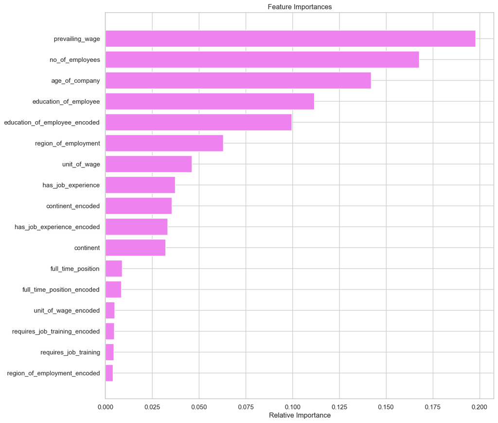

```python
feature_names = X_train.columns
importances = rf_tuned.feature_importances_
indices = np.argsort(importances)

plt.figure(figsize=(12,12))
plt.title('Feature Importances')
plt.barh(range(len(indices)), importances[indices], color='violet', align='center')
plt.yticks(range(len(indices)), [feature_names[i] for i in indices])
plt.xlabel('Relative Importance')
plt.show()
```

- prevailing_wage,no_of_employees,age_of_company,education_of_employee,region_of_employment, unit_of_wage,has_job_experience, continent, full_time_position, and requires_job_training are in decreasing order of their importance as captured by tuned random forest model

in determining whether or not visa application will be approved for the employees.

- The relative importance of encoded features are ignored because they cannot influence our prediction.

**Building Esemble Models**

**Building the model**

- We are going to build 3 ensemble models here - AdaBoost Classifier, Gradient Boosting Classifier and XGBoost Classifier.
- First, let's build these models with default parameters and then use hyperparameter tuning to optimize the model performance.
- We will calculate all three metrics - Accuracy, Precision and Recall but the metric of interest here is recall.
- Recall - It gives the ratio of True positives to Actual positives, so high Recall implies low false negatives, i.e. low chances of predicting an employee with certified visa status as employee with denied visa status.

**create functions to calculate different metrics and plot the confusion matrix.**

```python
## Function to create confusion matrix
def make_confusion_matrix(model,y_actual,labels=[1, 0]):
    '''
    model : classifier to predict values of X
    y_actual : ground truth

    '''
    y_predict = model.predict(X_test)
    cm=metrics.confusion_matrix( y_actual, y_predict, labels=[0, 1])
    df_cm = pd.DataFrame(cm, index = [i for i in ["Actual - No","Actual - Yes"]],
                  columns = [i for i in ['Predicted - No','Predicted - Yes']])
    group_counts = ["{0:0.0f}".format(value) for value in
                cm.flatten()]
    group_percentages = ["{0:.2%}".format(value) for value in
                         cm.flatten()/np.sum(cm)]
    labels = [f"{v1}\n{v2}" for v1, v2 in
              zip(group_counts,group_percentages)]
    labels = np.asarray(labels).reshape(2,2)
    plt.figure(figsize = (10,7))
    sns.heatmap(df_cm, annot=labels,fmt='')
    plt.ylabel('True label')
    plt.xlabel('Predicted label')
```

```python
# Function to calculate evaluation metrics
def calculate_metrics(model, X_train, X_test, y_train, y_test):
    # Fit the model
    model.fit(X_train, y_train)

    # Make predictions
    y_pred_train = model.predict(X_train)
    y_pred_test = model.predict(X_test)

    # Calculate evaluation metrics
    train_acc = accuracy_score(y_train, y_pred_train)
    test_acc = accuracy_score(y_test, y_pred_test)
    train_recall = recall_score(y_train, y_pred_train)
    test_recall = recall_score(y_test, y_pred_test)
    train_precision = precision_score(y_train, y_pred_train)
    test_precision = precision_score(y_test, y_pred_test)
    train_f1 = metrics.f1_score(y_train, pred_train)
    test_f1 = metrics.f1_score(y_test, pred_test)

    return train_acc, test_acc, train_recall, test_recall, train_precision, test_precision

# Function to plot confusion matrix
def plot_confusion_matrix(model, X_test, y_test, model_name):
    # Make predictions
    y_pred = model.predict(X_test)

    # Plot confusion matrix
    fig, ax = plt.subplots(figsize=(8, 6))
    cm = confusion_matrix(y_test, y_pred)
    sns.heatmap(cm, annot=True, fmt='d', cmap='Blues', ax=ax)
    ax.set_xlabel('Predicted labels')
    ax.set_ylabel('True labels')
    ax.set_title(f'Confusion Matrix - {model_name}')
    plt.show()
```

**AdaBoost Classifier**

```python
abc = AdaBoostClassifier(random_state=1)
abc.fit(X_train,y_train)
```

```
AdaBoostClassifier(random_state=1)
```

**Checking performance on Training set**

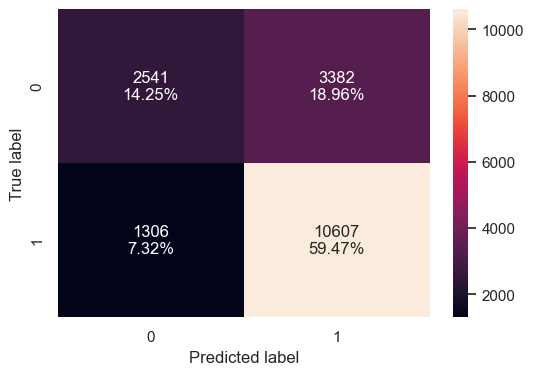

```python
confusion_matrix_sklearn(abc, X_train,y_train)
```

- True Positives (TP) and True Negatives (TN):

The confusion matrix indicates there are 10607 true positives (actual visa approvals predicted as approved) and 2541 true negatives (actual visa denials predicted as denied)

False Positives (FP) and False Negatives)

The model predicted 3382 visa denials as approvals (false positives) and 1306 visa approvals as denials (false negatives).

```python
# Check performance on the train data
abc_model_perf_train = model_performance_classification_sklearn(X_train, y_train, abc)

print("AdaBoost Model Performance on Training Data:")
print(abc_model_perf_train)
```

```
Accuracy: 0.7371607983852881
Precision: 0.7582386160554722
Recall: 0.8903718626710316
F1-score: 0.819010115049031
AdaBoost Model Performance on Training Data:
{'Accuracy': 0.7371607983852881, 'Precision': 0.7582386160554722, 'Recall': 0.8903718626710316, 'F1-score': 0.819010115049031}
```

**Checking performance on Testing set**

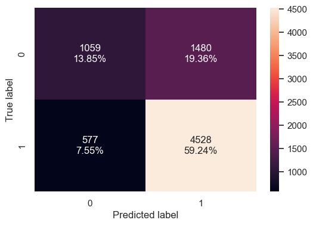

```python
confusion_matrix_sklearn(abc, X_test,y_test)
```

- True Positives (TP) and True Negatives (TN):The confusion matrix indicates there are 4528 true positives (actual visa approvals predicted as approved) and 1059 true negatives (actual visa denials predicted as denied).
- False Positives (FP) and False Negatives (FN):The model predicted 1480 visa denials as approvals (false positives) and 577 visa approvals as denials (false negatives).

```python
# Check performance on the test data
abc_model_perf_test = model_performance_classification_sklearn(X_test, y_test, abc)

print("AdaBoost Model Performance on Testing Data:")
print(abc_model_perf_test)
```

```
Accuracy: 0.7309000523286238
Precision: 0.7536617842876165
Recall: 0.886973555337904
F1-score: 0.8149014667506523
AdaBoost Model Performance on Testing Data:
{'Accuracy': 0.7309000523286238, 'Precision': 0.7536617842876165, 'Recall': 0.886973555337904, 'F1-score': 0.8149014667506523}
```

- Consistency in Metrics:

The AdaBoost model maintains consistent performance metrics (accuracy, precision, recall, and F1-score) on the training data, showcasing stability in its performance evaluation.

- The AdaBoost model demonstrates stable and reliable performance on the training data, with balanced precision, recall, and F1-score values.
- The model's ability to maintain consistent performance metrics indicates its effectiveness in correctly classifying instances and making accurate predictions.
- Continuous monitoring and validation on unseen data can further validate the model's generalization and predictive capabilities.

**Gradient Boosting Classifier**

```python
gbc = GradientBoostingClassifier(random_state=1)
gbc.fit(X_train,y_train)
```

```
GradientBoostingClassifier(random_state=1)
```

**Checking performance on Training set**

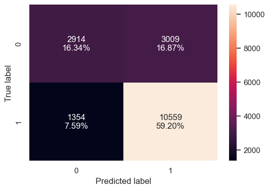

```python
confusion_matrix_sklearn(gbc, X_train,y_train)
```

- True Positives (TP) and True Negatives (TN):

The confusion matrix indicates there are 10559 true positives (actual visa approvals predicted as approved) and 2914 true negatives (actual visa denials predicted as denied).

False Positives (FP) and False Negatives)

The model predicted 3009 visa denials as approvals (false positives) and 1354 visa approvals as denials (false negatives).

```python
# Check performance on the train data
gbc_model_perf_train = model_performance_classification_sklearn(X_train, y_train, gbc)

print("GradientBoost Model Performance on Training Data:")
print(gbc_model_perf_train)
```

```
Accuracy: 0.7553823727293115
Precision: 0.7782281839622641
Recall: 0.8863426508855872
F1-score: 0.8287743809112672
GradientBoost Model Performance on Training Data:
{'Accuracy': 0.7553823727293115, 'Precision': 0.7782281839622641, 'Recall': 0.8863426508855872, 'F1-score': 0.8287743809112672}
```

**Checking performance on Testing set**

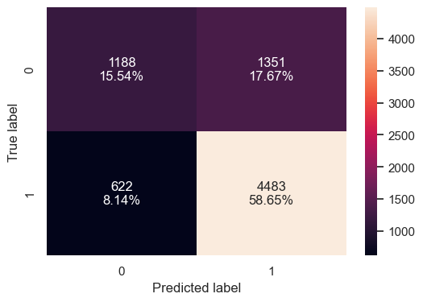

```python
confusion_matrix_sklearn(gbc, X_test,y_test)
```

False Positives (FP) and False Negatives)

The model predicted 1351 visa denials as approvals (false positives) and 622 visa approvals as denials (false negatives).

```python
# Check performance on the test data
gbc_model_perf_test = model_performance_classification_sklearn(X_test, y_test, gbc)

print("GradientBoost Model Performance on Testing Data:")
print(gbc_model_perf_test)
```

```
Accuracy: 0.7418890633176347
Precision: 0.7684264655467946
Recall: 0.8781586679725759
F1-score: 0.8196361641831976
GradientBoost Model Performance on Testing Data:
{'Accuracy': 0.7418890633176347, 'Precision': 0.7684264655467946, 'Recall': 0.8781586679725759, 'F1-score': 0.8196361641831976}
```

- Training vs. Testing Comparison:

The GradientBoost model exhibits slightly higher performance metrics (accuracy, precision, recall, and F1-score) on the training data compared to the testing data.

- The model displays a decent level of generalization from training to testing data, with close performance metrics reflecting its ability to maintain consistent predictive capabilities.

**XGBoost Classifier**

```python
xgb = XGBClassifier(random_state=1,eval_metric='logloss')
xgb.fit(X_train,y_train)
```

```
XGBClassifier(base_score=None, booster=None, callbacks=None,
              colsample_bylevel=None, colsample_bynode=None,
              colsample_bytree=None, device=None, early_stopping_rounds=None,
              enable_categorical=False, eval_metric='logloss',
              feature_types=None, gamma=None, grow_policy=None,
              importance_type=None, interaction_constraints=None,
              learning_rate=None, max_bin=None, max_cat_threshold=None,
              max_cat_to_onehot=None, max_delta_step=None, max_depth=None,
              max_leaves=None, min_child_weight=None, missing=nan,
              monotone_constraints=None, multi_strategy=None, n_estimators=None,
              n_jobs=None, num_parallel_tree=None, random_state=1, ...)
```

**Checking performance on Training set**

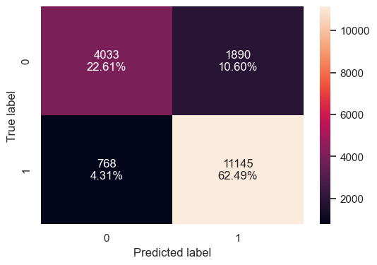

```python
confusion_matrix_sklearn(xgb, X_train,y_train)
```

- True Positives (TP) and True Negatives (TN):The confusion matrix indicates there are 11145 true positives (actual visa approvals predicted as approved) and 4033 true negatives (actual visa denials predicted as denied).
- False Positives (FP) and False Negatives (FN):The model predicted 1890 visa denials as approvals (false positives) and 768 visa approvals as denials (false negatives).

```python
# Check performance on the train data
xgb_model_perf_train = model_performance_classification_sklearn(X_train, y_train, xgb)

print("XGBoost Model Performance on Training Data:")
print(xgb_model_perf_train)
```

```
Accuracy: 0.8509755550571877
Precision: 0.8550057537399309
Recall: 0.9355326114328885
F1-score: 0.8934583934583935
XGBoost Model Performance on Training Data:
{'Accuracy': 0.8509755550571877, 'Precision': 0.8550057537399309, 'Recall': 0.9355326114328885, 'F1-score': 0.8934583934583935}
```

**Checking performance on Testing set**

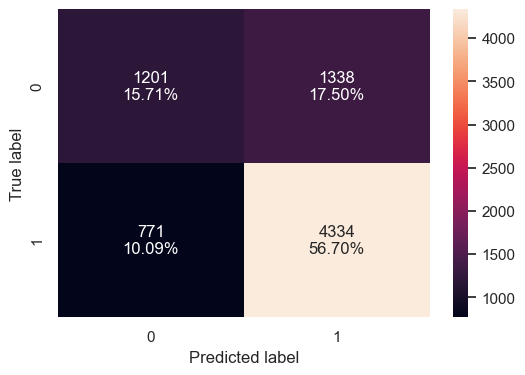

```python
confusion_matrix_sklearn(xgb, X_test,y_test)
```

- True Positives (TP) and True Negatives (TN):

The confusion matrix indicates there are 4334 true positives (actual visa approvals predicted as approved) and 1201 true negatives (actual visa denials predicted as denied).

False Positives (FP) and False Negatives)

The model predicted 1338 visa denials as approvals (false positives) and 771 visa approvals as denials (false negatives).

```python
# Check performance on the test data
xgb_model_perf_test = model_performance_classification_sklearn(X_test, y_test, xgb)

print("XGBoost Model Performance on Testing Data:")
print(xgb_model_perf_test)
```

```
Accuracy: 0.7240973312401884
Precision: 0.7641043723554302
Recall: 0.8489715964740451
F1-score: 0.8043054653428598
XGBoost Model Performance on Testing Data:
{'Accuracy': 0.7240973312401884, 'Precision': 0.7641043723554302, 'Recall': 0.8489715964740451, 'F1-score': 0.8043054653428598}
```

- Training vs. Testing Data:

- There is a noticeable drop in performance metrics from training to testing data, suggesting a need for model adjustments to improve generalization and performance on unseen datasets.

## Will tuning the hyperparameters improve the model performance?

**Hperparameter Tuning- AdaBoost Classifier**

- An AdaBoost classifier is a meta-estimator that begins by fitting a classifier on the original dataset and then fits additional copies of the classifier on the same dataset but where the weights of incorrectly classified instances are adjusted such that subsequent classifiers focus more on difficult cases.
- Some important hyperparamters are:
  - base_estimator: The base estimator from which the boosted ensemble is built.
  - By default the base estimator is a decision tree with max_dept=1.
  - n_estimators: The maximum number of estimators at which boosting is terminatedDefault value is 50.

```python
# Choose the type of classifier.
abc_tuned = AdaBoostClassifier(random_state=1)

# Grid of parameters to choose from
## add from article
parameters = {
    "n_estimators": np.arange(50,110,25),
    "learning_rate": [0.01,0.1,0.05],
    "base_estimator": [
        DecisionTreeClassifier(max_depth=2, random_state=1),
        DecisionTreeClassifier(max_depth=3, random_state=1),
    ],
}
# Type of scoring used to compare parameter combinations
acc_scorer = metrics.make_scorer(metrics.recall_score)

# Run the grid search
grid_obj = GridSearchCV(abc_tuned, parameters, scoring=acc_scorer,cv=5)
grid_obj = grid_obj.fit(X_train, y_train)

# Set the clf to the best combination of parameters
abc_tuned = grid_obj.best_estimator_

# Fit the best algorithm to the data.
abc_tuned.fit(X_train, y_train)
```

```
AdaBoostClassifier(base_estimator=DecisionTreeClassifier(max_depth=2,
                                                         random_state=1),
                   learning_rate=0.01, random_state=1)
```

**Checking performance on Training set**

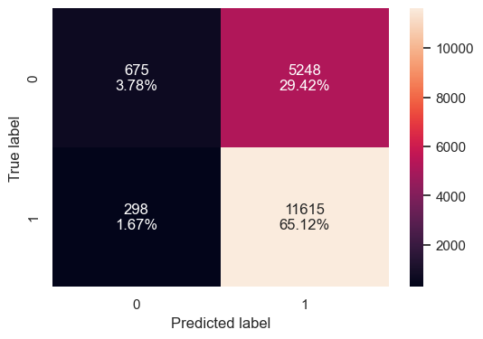

```python
confusion_matrix_sklearn(abc_tuned, X_train,y_train)
```

- True Positives (TP) and True Negatives (TN):

The confusion matrix reveals 11615 true positives (actual visa approvals predicted as approved) and 675 true negatives (actual visa denials predicted as denied).

False Positives (FP) and False Negatives

The model incorrectly labeled 5248 visa denials as approvals (false positives) and 298 visa approvals as denials (false negatives).

```python
# Check performance on the train data
abc_tune_model_perf_train = model_performance_classification_sklearn(X_train, y_train,abc_tuned)

print("AdaBoost Tune Model Performance on Training Data:")
print(abc_tune_model_perf_train)
```

```
Accuracy: 0.6890558421170666
Precision: 0.6887860997450038
Recall: 0.9749853101653656
F1-score: 0.8072699471782041
AdaBoost Tune Model Performance on Training Data:
{'Accuracy': 0.6890558421170666, 'Precision': 0.6887860997450038, 'Recall': 0.9749853101653656, 'F1-score': 0.8072699471782041}
```

**Checking performance on Testing set**

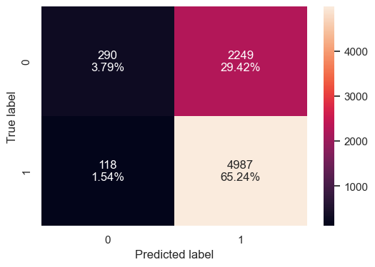

```python
confusion_matrix_sklearn(abc_tuned, X_test,y_test)
```

- True Positives (TP) and True Negatives (TN):

The confusion matrix shows there are 4987 true positives (actual visa approvals predicted as approved) and 290 true negatives (actual visa denials predicted as denied).

False Positives (FP) and False Negatives)

The model incorrectly classified 2249 visa denials as approvals (false positives) and 118 visa approvals as denials (false negatives).

```python
# Check performance on the test data
abc_tune_model_perf_test = model_performance_classification_sklearn(X_test, y_test, abc_tuned)

print("AdaBoost Tune Model Performance on Testing Data:")
print(abc_tune_model_perf_test)
```

```
Accuracy: 0.6903453689167975
Precision: 0.6891929242675512
Recall: 0.9768854064642507
F1-score: 0.8082003079167004
AdaBoost Tune Model Performance on Testing Data:
{'Accuracy': 0.6903453689167975, 'Precision': 0.6891929242675512, 'Recall': 0.9768854064642507, 'F1-score': 0.8082003079167004}
```

- Training vs. Testing Data:

The model exhibits consistent performance metrics (accuracy, precision, recall, and F1-score) between the training and testing datasets, indicating good generalization capabilities.

- The model demonstrates consistent performance and good generalization from training to testing data, with similar metrics indicating stable predictive capabilities across different datasets.

```python
print(pd.DataFrame(abc_tuned.feature_importances_, columns = ["Imp"], index = X_train.columns).sort_values(by = 'Imp', ascending = False))
```

```
                                    Imp
education_of_employee_encoded  0.239991
unit_of_wage                   0.203623
education_of_employee          0.197957
has_job_experience             0.143271
has_job_experience_encoded     0.138330
prevailing_wage                0.076828
continent                      0.000000
requires_job_training_encoded  0.000000
region_of_employment_encoded   0.000000
unit_of_wage_encoded           0.000000
full_time_position_encoded     0.000000
full_time_position             0.000000
continent_encoded              0.000000
region_of_employment           0.000000
no_of_employees                0.000000
requires_job_training          0.000000
age_of_company                 0.000000
```

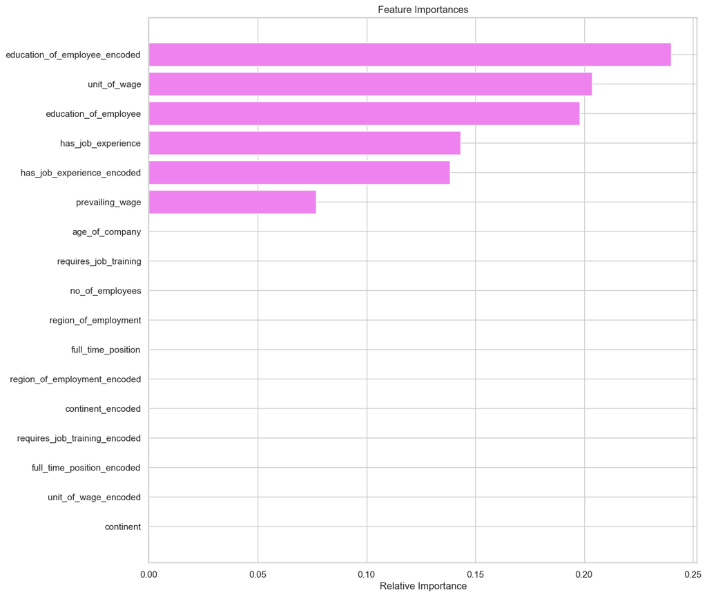

```python
importances = abc_tuned.feature_importances_
indices = np.argsort(importances)
feature_names = list(X.columns)

plt.figure(figsize=(12,12))
plt.title('Feature Importances')
plt.barh(range(len(indices)), importances[indices], color='violet', align='center')
plt.yticks(range(len(indices)), [feature_names[i] for i in indices])
plt.xlabel('Relative Importance')
plt.show()
```

- unit_of_wage, education_of_employee,has_job_experience, and prevaling_wage are in decreasing order of their importance as captured by tuned Adaboost model in

- The relative importance of encoded features are ignored because they cannot influence our prediction.

**Gradient Boosting Classifier**

- Most of the hyperparameters available are same as random forest classifier
- init: An estimator object that is used to compute the initial predictions. If ‘zero’, the initial raw predictions are set to zero. By default, a DummyEstimator predicting the classes priors is used.

There is no class_weights parameter in gradient boostng.s

**Let's try using AdaBoost classifier as the estimator for initial predictions**

```python
gbc_init = GradientBoostingClassifier(init=AdaBoostClassifier(random_state=1),random_state=1)
gbc_init.fit(X_train,y_train)
```

```
GradientBoostingClassifier(init=AdaBoostClassifier(random_state=1),
                           random_state=1)
```

**Checking performance on Training set**

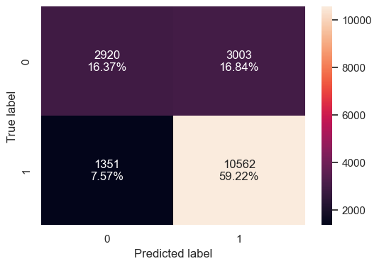

```python
confusion_matrix_sklearn(gbc_init, X_train,y_train)
```

- True Positives (TP) and True Negatives (TN):

The confusion matrix reveals 10562 true positives (actual visa approvals predicted as approved) and 2920 true negatives (actual visa denials predicted as denied).

False Positives (FP) and False Negatives)

The model incorrectly classified 3003 visa denials as approvals (false positives) and 1351 visa approvals as denials (false negatives).

```python
# Check performance on the train data
gbc_init_model_perf_train = model_performance_classification_sklearn(X_train, y_train, gbc_init)

print("GradientBoost-Init Model Performance on Training Data:")
print(gbc_init_model_perf_train)
```

```
Accuracy: 0.7558869701726845
Precision: 0.7786214522668633
Recall: 0.8865944766221775
F1-score: 0.8291074652641495
GradientBoost-Init Model Performance on Training Data:
{'Accuracy': 0.7558869701726845, 'Precision': 0.7786214522668633, 'Recall': 0.8865944766221775, 'F1-score': 0.8291074652641495}
```

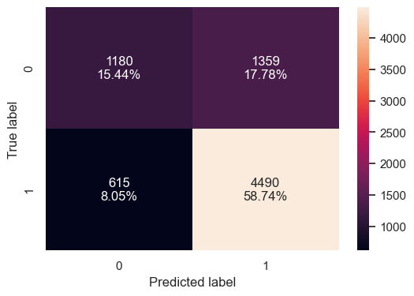

```python
confusion_matrix_sklearn(gbc_init, X_test,y_test)
```

- True Positives (TP) and True Negatives (TN):

The confusion matrix indicates there are 4490 true positives (actual visa approvals predicted as approved) and 1180 true negatives (actual visa denials predicted as denied).

False Positives (FP) and False Negatives)

The model predicted 1359 visa denials as approvals (false positives) and 615 visa approvals as denials (false negatives).

```python
# Check performance on the test data
gbc_init_model_perf_test = model_performance_classification_sklearn(X_test, y_test, gbc_init)

print("GradientBoost-Init Performance on Testing Data:")
print(gbc_init_model_perf_test)
```

```
Accuracy: 0.7417582417582418
Precision: 0.7676525901863567
Recall: 0.8795298726738492
F1-score: 0.8197918568559431
GradientBoost-Init Performance on Testing Data:
{'Accuracy': 0.7417582417582418, 'Precision': 0.7676525901863567, 'Recall': 0.8795298726738492, 'F1-score': 0.8197918568559431}
```

- Training vs. Testing Data:

There is a slight drop in performance metrics from the training to the testing data, indicating some loss of generalization and possibly slight overfittig.

- The GradientBoost-Init model displays strong performance on the training data and good performance on the testing data, with balanced precision, recall, and F1-score.
- The model demonstrates slightly reduced performance on the testing data compared to the training data, suggesting a need for adjustments to improve generalization and maintain robust performance across different datasets.

```python
# Choose the type of classifier.
gbc_tuned = GradientBoostingClassifier(init=AdaBoostClassifier(random_state=1),random_state=1)

# Grid of parameters to choose from
## add from article
parameters = {
    "init": [AdaBoostClassifier(random_state=1),DecisionTreeClassifier(random_state=1)],
    "n_estimators": np.arange(50,110,25),
    "learning_rate": [0.01,0.1,0.05],
    "subsample":[0.7,0.9],
    "max_features":[0.5,0.7,1],
}
# Type of scoring used to compare parameter combinations
acc_scorer = metrics.make_scorer(metrics.recall_score)

# Run the grid search
grid_obj = GridSearchCV(gbc_tuned, parameters, scoring=acc_scorer,cv=5)
grid_obj = grid_obj.fit(X_train, y_train)

# Set the clf to the best combination of parameters
gbc_tuned = grid_obj.best_estimator_

# Fit the best algorithm to the data.
gbc_tuned.fit(X_train, y_train)
```

```
GradientBoostingClassifier(init=AdaBoostClassifier(random_state=1),
                           learning_rate=0.01, max_features=1, n_estimators=50,
                           random_state=1, subsample=0.9)
```

**Checking performance on Training set**

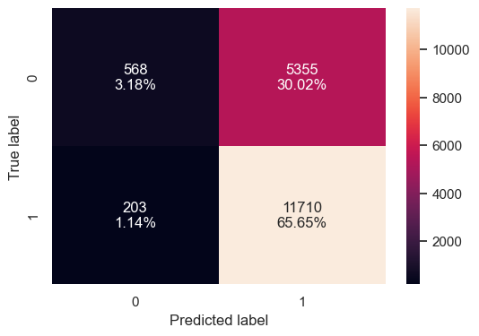

```python
confusion_matrix_sklearn(gbc_tuned, X_train,y_train)
```

- True Positives (TP) and True Negatives (TN):

The confusion matrix indicates there are 11710 true positives (actual visa approvals predicted as approved) and 568 true negatives (actual visa denials predicted as denied)

False Positives (FP) and False Negatives)

The model predicted 5355 visa denials as approvals (false positives) and 203 visa approvals as denials (false negatives).

```python
# Check performance on the train data
gbc_tune_model_perf_train = model_performance_classification_sklearn(X_train, y_train, gbc_tuned)

print("GradientBoost Tune Model Performance on Training Data:")
print(gbc_tune_model_perf_train)
```

```
Accuracy: 0.6883830455259027
Precision: 0.6861998242015822
Recall: 0.9829597918240578
F1-score: 0.8081993236248189
GradientBoost Tune Model Performance on Training Data:
{'Accuracy': 0.6883830455259027, 'Precision': 0.6861998242015822, 'Recall': 0.9829597918240578, 'F1-score': 0.8081993236248189}
```

**Checking performance on Testing set**

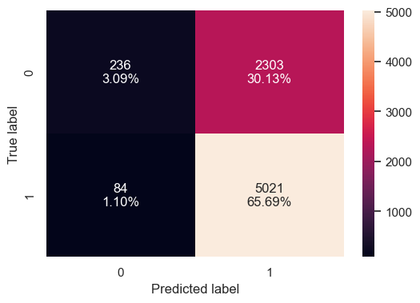

```python
confusion_matrix_sklearn(gbc_tuned, X_test,y_test)
```

- True Positives (TP) and True Negatives (TN):

The confusion matrix indicates there are 5021 true positives (actual visa approvals predicted as approved) and 236 true negatives (actual visa denials predicted as denied).

False Positives (FP) and False Negatives)

The model misclassified 2303 visa denials as approvals (false positives) and 84 visa approvals as denials (false negatives).

```python
# Check performance on the test data
gbc_tune_model_perf_test = model_performance_classification_sklearn(X_test, y_test, gbc_tuned)

print("GradientBoost Tune Performance on Testing Data:")
print(gbc_tune_model_perf_test)
```

```
Accuracy: 0.6877289377289377
Precision: 0.6855543418896778
Recall: 0.9835455435847209
F1-score: 0.8079491511786949
GradientBoost Tune Performance on Testing Data:
{'Accuracy': 0.6877289377289377, 'Precision': 0.6855543418896778, 'Recall': 0.9835455435847209, 'F1-score': 0.8079491511786949}
```

- Training vs.Testing Data:

The model shows similar performance metrics between the training and testing datasets, indicating consistent performance and good generalizatino

```python
print(pd.DataFrame(gbc_tuned.feature_importances_, columns = ["Imp"], index = X_train.columns).sort_values(by = 'Imp', ascending = False))
```

```
                                    Imp
prevailing_wage                0.229385
education_of_employee          0.168941
education_of_employee_encoded  0.157921
has_job_experience_encoded     0.119970
has_job_experience             0.117367
unit_of_wage                   0.096207
continent_encoded              0.031959
region_of_employment           0.024033
continent                      0.020822
age_of_company                 0.010817
no_of_employees                0.005457
requires_job_training          0.004223
full_time_position_encoded     0.003494
unit_of_wage_encoded           0.002741
full_time_position             0.002620
region_of_employment_encoded   0.002208
requires_job_training_encoded  0.001834
```

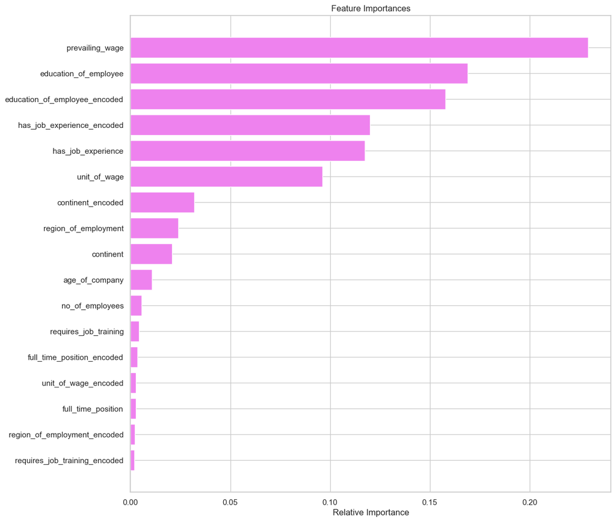

```python
importances = gbc_tuned.feature_importances_
indices = np.argsort(importances)
feature_names = list(X.columns)

plt.figure(figsize=(12,12))
plt.title('Feature Importances')
plt.barh(range(len(indices)), importances[indices], color='violet', align='center')
plt.yticks(range(len(indices)), [feature_names[i] for i in indices])
plt.xlabel('Relative Importance')
plt.show()
```

- prevailing_wage,education_of_employee, has_job_experience,unit_of_wage, region_of_employment,continent, age_of_company,no_of_employees,requires_job_training,and full_time_position are in decreasing order of their importance as captured by tuned gradient boost model in determining whether or not visa application will be approved for the employees.
- The relative importance of encoded features are ignored because they cannot influence our prediction.

**XGBoost Classifier**

**XGBoost has many hyper parameters which can be tuned to increase the model performance. You can read about them in the xgboost documentation here. Some of the important parameters are:**

- scale_pos_weight:Control the balance of positive and negative weights, useful for unbalanced classes. It has range from 0 to ∞.

subsample: Corresponds to the fraction of observations (the rows) to subsample at each step. By default it is set to 1 meaning that we use all row

max_depth: is the maximum number of nodes allowed from the root to the farthest leaf of a

- tree.

- step.

gamma: A node is split only when the resulting split gives a positive reduction in the loss function. Gamma specifies the minimum loss reduction required to make a split.a split.

```python
# Choose the type of classifier.
xgb_tuned = XGBClassifier(random_state=1,eval_metric='logloss')

# Grid of parameters to choose from
## add from
parameters ={'n_estimators':np.arange(50,110,25),
            'scale_pos_weight':[1,2,5],
            'learning_rate':[0.01,0.1,0.05],
            'gamma':[1,3],
            'subsample':[0.7,0.9]
}

# Type of scoring used to compare parameter combinations
acc_scorer = metrics.make_scorer(metrics.recall_score)

# Run the grid search
grid_obj = GridSearchCV(xgb_tuned, parameters,scoring=acc_scorer,cv=5)
grid_obj = grid_obj.fit(X_train, y_train)

# Set the clf to the best combination of parameters
xgb_tuned = grid_obj.best_estimator_

# Fit the best algorithm to the data.
xgb_tuned.fit(X_train, y_train)
```

```
XGBClassifier(base_score=None, booster=None, callbacks=None,
              colsample_bylevel=None, colsample_bynode=None,
              colsample_bytree=None, device=None, early_stopping_rounds=None,
              enable_categorical=False, eval_metric='logloss',
              feature_types=None, gamma=1, grow_policy=None,
              importance_type=None, interaction_constraints=None,
              learning_rate=0.01, max_bin=None, max_cat_threshold=None,
              max_cat_to_onehot=None, max_delta_step=None, max_depth=None,
              max_leaves=None, min_child_weight=None, missing=nan,
              monotone_constraints=None, multi_strategy=None, n_estimators=50,
              n_jobs=None, num_parallel_tree=None, random_state=1, ...)
```

**Checking performance on Training set**

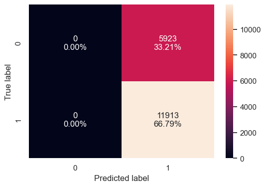

```python
confusion_matrix_sklearn(xgb_tuned, X_train,y_train)
```

- True Positives (TP): 11913 (Visa Approved instances correctly predicted as Approved).

```python
# Check performance on the train data
xgb_tune_model_perf_train = model_performance_classification_sklearn(X_train, y_train, xgb_tuned)

print("XGBoost Tune Model Performance on Training Data:")
print(xgb_tune_model_perf_train)
```

```
Accuracy: 0.6679188158779995
Precision: 0.6679188158779995
Recall: 1.0
F1-score: 0.8009008706174997
XGBoost Tune Model Performance on Training Data:
{'Accuracy': 0.6679188158779995, 'Precision': 0.6679188158779995, 'Recall': 1.0, 'F1-score': 0.8009008706174997}
```

**Checking performance on Testing set**

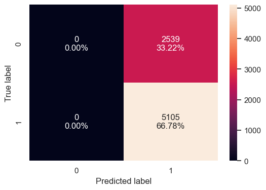

```python
confusion_matrix_sklearn(xgb_tuned, X_test,y_test)
```

- True Positives (TP): 5105 (Visa Approved instances correctly predicted as Approved).

True Negatives (TN): 0 (Visa Denied instances correctly predicted as Denied)

```python
# Check performance on the test data
xgb_tune_model_perf_test = model_performance_classification_sklearn(X_test, y_test, xgb_tuned)

print("XGBoost Tune Performance on Testing Data:")
print(xgb_tune_model_perf_test)
```

```
Accuracy: 0.6678440607012036
Precision: 0.6678440607012036
Recall: 1.0
F1-score: 0.8008471252647267
XGBoost Tune Performance on Testing Data:
{'Accuracy': 0.6678440607012036, 'Precision': 0.6678440607012036, 'Recall': 1.0, 'F1-score': 0.8008471252647267}
```

```python
print(pd.DataFrame(xgb_tuned.feature_importances_, columns = ["Imp"], index = X_train.columns).sort_values(by = 'Imp', ascending = False))
```

```
                                    Imp
unit_of_wage                   0.480298
education_of_employee          0.299798
has_job_experience             0.104626
continent                      0.026866
region_of_employment           0.019402
full_time_position             0.019315
requires_job_training          0.016852
prevailing_wage                0.014173
age_of_company                 0.009663
no_of_employees                0.009007
continent_encoded              0.000000
education_of_employee_encoded  0.000000
requires_job_training_encoded  0.000000
has_job_experience_encoded     0.000000
full_time_position_encoded     0.000000
unit_of_wage_encoded           0.000000
region_of_employment_encoded   0.000000
```

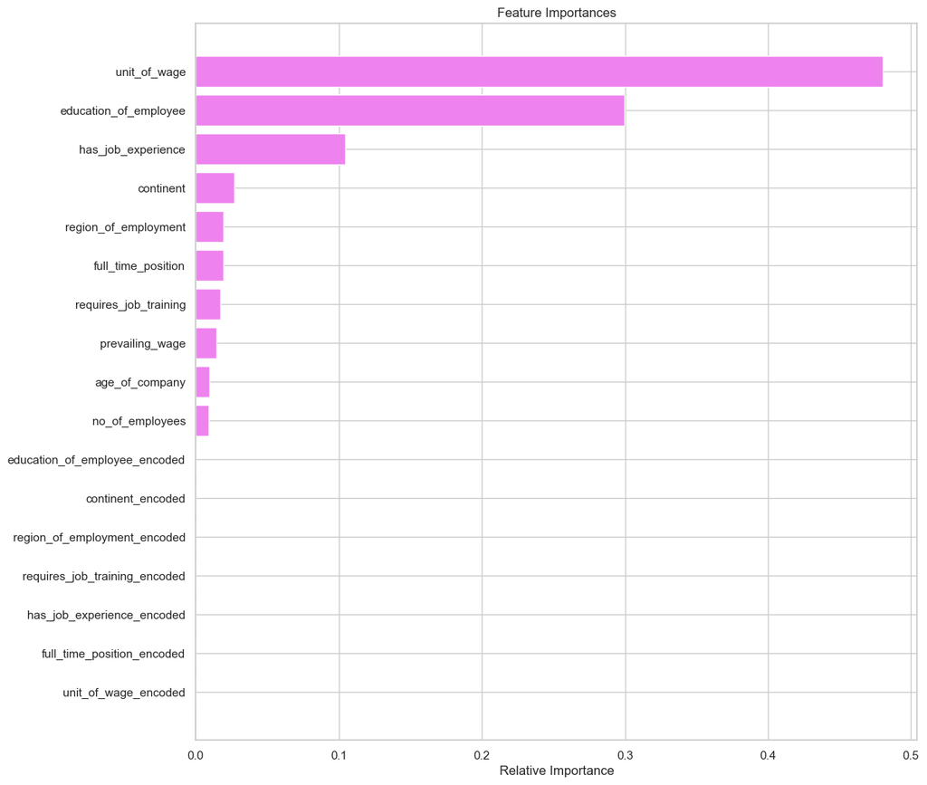

```python
importances = xgb_tuned.feature_importances_
indices = np.argsort(importances)
feature_names = list(X.columns)

plt.figure(figsize=(12,12))
plt.title('Feature Importances')
plt.barh(range(len(indices)), importances[indices], color='violet', align='center')
plt.yticks(range(len(indices)), [feature_names[i] for i in indices])
plt.xlabel('Relative Importance')
plt.show()
```

- unit_of_wage,education_of_employee,has_job_experience,continent, region_of_employment, full_time_position, requires_job_training, prevailing_wage, age_of_company,and no_of_employees are in decreasing order of their importance as captured by tuned XGBoost model in determining whether or not visa application will be approved for the employees.
- The relative importance of encoded features are ignored because they cannot influence our prediction.

**Stacking Model**

**We build a stacking model with the tuned models - decision tree, random forest, and gradient boosting, then use XGBoost to get the final prediction.**

```python
estimators=[('Decision Tree', dtree_tuned),('Random Forest', rf_tuned),
           ('Gradient Boosting', gbc_tuned)]
final_estimator=XGBClassifier(random_state=1)
```

```python
from sklearn.ensemble import StackingClassifier

# Create the Stacking RClassifier with the corrected final estimator
stacking_estimator = StackingClassifier(estimators=estimators, final_estimator=final_estimator, cv=5)

# Fit the Stacking Regressor to the training data
stacking_estimator.fit(X_train, y_train)
```

```
StackingClassifier(cv=5,
                   estimators=[('Decision Tree',
                                DecisionTreeClassifier(class_weight='balanced',
                                                       max_depth=5,
                                                       max_leaf_nodes=10,
                                                       min_impurity_decrease=0.0001,
                                                       random_state=1)),
                               ('Random Forest',
                                RandomForestClassifier(max_samples=0.4,
                                                       min_samples_leaf=3,
                                                       n_estimators=25,
                                                       random_state=1)),
                               ('Gradient Boosting',
                                GradientBoostingClassifier(init=AdaBoostClassifi...
                                                 feature_types=None, gamma=None,
                                                 grow_policy=None,
                                                 importance_type=None,
                                                 interaction_constraints=None,
                                                 learning_rate=None,
                                                 max_bin=None,
                                                 max_cat_threshold=None,
                                                 max_cat_to_onehot=None,
                                                 max_delta_step=None,
                                                 max_depth=None,
                                                 max_leaves=None,
                                                 min_child_weight=None,
                                                 missing=nan,
                                                 monotone_constraints=None,
                                                 multi_strategy=None,
                                                 n_estimators=None, n_jobs=None,
                                                 num_parallel_tree=None,
                                                 random_state=1, ...))
```

**Checking performance on Training set**

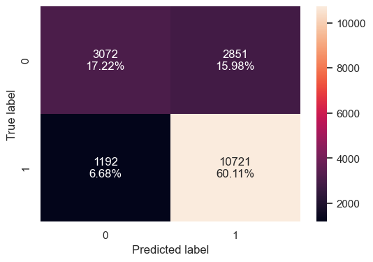

```python
confusion_matrix_sklearn(stacking_estimator, X_train,y_train)
```

- True Positives (TP): 10721 (Visa Approved instances correctly predicted as Approved).

True Negatives (TN): 3072 (Visa Denied instances correctly predicted as Denied)

```python
# Check performance on the train data
stacking_estimator_model_perf_train = model_performance_classification_sklearn(X_train, y_train, stacking_estimator)

print("Stacking Estimator Model Performance on Training Data:")
print(stacking_estimator_model_perf_train)
```

```
Accuracy: 0.7733236151603499
Precision: 0.7899351606248158
Recall: 0.8999412406614623
F1-score: 0.841357661369433
Stacking Estimator Model Performance on Training Data:
{'Accuracy': 0.7733236151603499, 'Precision': 0.7899351606248158, 'Recall': 0.8999412406614623, 'F1-score': 0.841357661369433}
```

**Checking performance on Testing set**

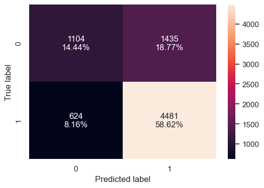

```python
confusion_matrix_sklearn(stacking_estimator, X_test,y_test)
```

- True Positives (TP): 4481 (Visa Approved instances correctly predicted as Approved).

True Negatives (TN): 1104 (Visa Denied instances correctly predicted as Deni.ed)

```python
# Check performance on the test data
stacking_estimator_model_perf_test = model_performance_classification_sklearn(X_test, y_test, stacking_estimator)

print("Stacking Estimator Tune Performance on Testing Data:")
print(stacking_estimator_model_perf_test)
```

```
Accuracy: 0.7306384092098378
Precision: 0.7574374577417173
Recall: 0.8777668952007835
F1-score: 0.8131748480174213
Stacking Estimator Tune Performance on Testing Data:
{'Accuracy': 0.7306384092098378, 'Precision': 0.7574374577417173, 'Recall': 0.8777668952007835, 'F1-score': 0.8131748480174213}
```

- The Stacking Estimator Model demonstrates notable performance on both training and testing data, showcasing a good balance between precision and recall.
- The model exhibits consistent accuracy across datasets, emphasizing its robustness in making accurate predictions.
- The recall values indicate the model's effectiveness in capturing positive instances, thereby contributing to its overall performance.

Further analysis and potential model adjustments could be explored to fine-tune the model's performance and address any specific areas that may benefit from optimization.

```python
# Calculate feature importances manually by averaging the feature importances from base estimators
importances = np.mean([estimator.feature_importances_ for estimator in stacking_estimator.estimators_], axis=0)

# Correcting the DataFrame creation to align with the shape of the passed values and the indices
importances_df = pd.DataFrame(importances.reshape(-1, 1), columns=["Imp"], index=X_train.columns[:len(importances)])
importances_df = importances_df.sort_values(by='Imp', ascending=False)

print(importances_df)
```

```
                                    Imp
education_of_employee          0.217548
education_of_employee_encoded  0.159703
prevailing_wage                0.142410
has_job_experience             0.113261
unit_of_wage                   0.090572
has_job_experience_encoded     0.069850
no_of_employees                0.057725
age_of_company                 0.050898
region_of_employment           0.033587
continent                      0.024740
continent_encoded              0.022427
full_time_position_encoded     0.003961
full_time_position             0.003815
requires_job_training          0.002853
unit_of_wage_encoded           0.002528
requires_job_training_encoded  0.002109
region_of_employment_encoded   0.002013
```

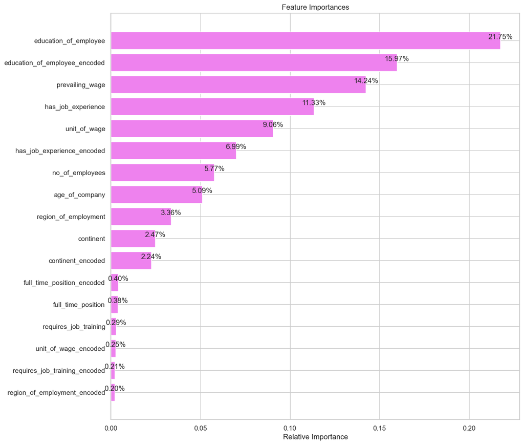

```python
# Calculate the mean feature importances across all trees in the StackingClassifier
feature_names = X_train.columns
importances = np.mean([tree.feature_importances_ for tree in stacking_estimator.estimators_], axis=0)
indices = np.argsort(importances)

plt.figure(figsize=(12, 12))
plt.title('Feature Importances')

# Plot the horizontal bar chart with feature importances and percentages on each bar
bar_plot = plt.barh(range(len(indices)), importances[indices], color='violet', align='center')
plt.yticks(range(len(indices)), [feature_names[i] for i in indices])

# Add percentage labels on each bar
for i in range(len(indices)):
    plt.text(importances[indices][i], i, f'{importances[indices][i]*100:.2f}%', ha='center', va='bottom')

plt.xlabel('Relative Importance')
plt.show()
```

- The Stacking estimator indicate the percentage of relative importance of features in the above plot in determining whether or not visa application will be approved for the employees.
- The relative importance of encoded features are ignored because they cannot influence our prediction.

**Model Performance Comparison and Final Model Selection**

```python
from tabulate import tabulate

from sklearn.metrics import accuracy_score, precision_score, recall_score, f1_score

model_names = [
    "Decision Tree", "Tuned Decision Tree", "Bagging", "Bagging with Weighted Samples",
    "Tuned Bagging", "Random Forest", "Random Forest with Weighted Samples", "Tuned Random Forest",
    "AdaBoost", "Tuned AdaBoost", "Gradient Boosting", "Initial Gradient Boosting",
    "Tuned Gradient Boosting", "XGBoost", "Tuned XGBoost", "Stacking Estimator"
]

models = [
    dtree, dtree_tuned, bagging, bagging_wt, bagging_tuned, rf, rf_wt, rf_tuned, abc, abc_tuned, gbc,
    gbc_init, gbc_tuned, xgb, xgb_tuned, stacking_estimator
]

metrics_table_train = []
metrics_table_test = []

for name, model in zip(model_names, models):
    pred_train = model.predict(X_train)
    pred_test = model.predict(X_test)

    accuracy_train = accuracy_score(y_train, pred_train)
    precision_train = precision_score(y_train, pred_train)
    recall_train = recall_score(y_train, pred_train)
    f1_train = f1_score(y_train, pred_train)

    accuracy_test = accuracy_score(y_test, pred_test)
    precision_test = precision_score(y_test, pred_test)
    recall_test = recall_score(y_test, pred_test)
    f1_test = f1_score(y_test, pred_test)

    metrics_table_train.append([name, accuracy_train, precision_train, recall_train, f1_train])
    metrics_table_test.append([name, accuracy_test, precision_test, recall_test, f1_test])

headers = ["Model", "Accuracy", "Precision", "Recall", "F1-Score"]

print("Training Set Performance:")
print(tabulate(metrics_table_train, headers=headers, tablefmt="grid"))
print("\n")
print("Testing Set Performance:")
print(tabulate(metrics_table_test, headers=headers, tablefmt="grid"))
```

```
Training Set Performance:
+-------------------------------------+------------+-------------+----------+------------+
| Model                               |   Accuracy |   Precision |   Recall |   F1-Score |
+=====================================+============+=============+==========+============+
| Decision Tree                       |   1        |    1        | 1        |   1        |
+-------------------------------------+------------+-------------+----------+------------+
| Tuned Decision Tree                 |   0.688663 |    0.818191 | 0.686393 |   0.746519 |
+-------------------------------------+------------+-------------+----------+------------+
| Bagging                             |   0.985815 |    0.992066 | 0.986653 |   0.989352 |
+-------------------------------------+------------+-------------+----------+------------+
| Bagging with Weighted Samples       |   0.984694 |    0.992719 | 0.984303 |   0.988493 |
+-------------------------------------+------------+-------------+----------+------------+
| Tuned Bagging                       |   0.997477 |    0.996569 | 0.999664 |   0.998114 |
+-------------------------------------+------------+-------------+----------+------------+
| Random Forest                       |   0.999944 |    1        | 0.999916 |   0.999958 |
+-------------------------------------+------------+-------------+----------+------------+
| Random Forest with Weighted Samples |   1        |    1        | 1        |   1        |
+-------------------------------------+------------+-------------+----------+------------+
| Tuned Random Forest                 |   0.802646 |    0.815218 | 0.911022 |   0.860461 |
+-------------------------------------+------------+-------------+----------+------------+
| AdaBoost                            |   0.737161 |    0.758239 | 0.890372 |   0.81901  |
+-------------------------------------+------------+-------------+----------+------------+
| Tuned AdaBoost                      |   0.689056 |    0.688786 | 0.974985 |   0.80727  |
+-------------------------------------+------------+-------------+----------+------------+
| Gradient Boosting                   |   0.755382 |    0.778228 | 0.886343 |   0.828774 |
+-------------------------------------+------------+-------------+----------+------------+
| Initial Gradient Boosting           |   0.755887 |    0.778621 | 0.886594 |   0.829107 |
+-------------------------------------+------------+-------------+----------+------------+
| Tuned Gradient Boosting             |   0.688383 |    0.6862   | 0.98296  |   0.808199 |
+-------------------------------------+------------+-------------+----------+------------+
| XGBoost                             |   0.850976 |    0.855006 | 0.935533 |   0.893458 |
+-------------------------------------+------------+-------------+----------+------------+
| Tuned XGBoost                       |   0.667919 |    0.667919 | 1        |   0.800901 |
+-------------------------------------+------------+-------------+----------+------------+
| Stacking Estimator                  |   0.773324 |    0.789935 | 0.899941 |   0.841358 |
+-------------------------------------+------------+-------------+----------+------------+


Testing Set Performance:
+-------------------------------------+------------+-------------+----------+------------+
```

[output cut: 19 more lines]

```
+-------------------------------------+------------+-------------+----------+------------+
| Tuned AdaBoost                      |   0.690345 |    0.689193 | 0.976885 |   0.8082   |
+-------------------------------------+------------+-------------+----------+------------+
| Gradient Boosting                   |   0.741889 |    0.768426 | 0.878159 |   0.819636 |
+-------------------------------------+------------+-------------+----------+------------+
| Initial Gradient Boosting           |   0.741758 |    0.767653 | 0.87953  |   0.819792 |
+-------------------------------------+------------+-------------+----------+------------+
| Tuned Gradient Boosting             |   0.687729 |    0.685554 | 0.983546 |   0.807949 |
+-------------------------------------+------------+-------------+----------+------------+
| XGBoost                             |   0.724097 |    0.764104 | 0.848972 |   0.804305 |
+-------------------------------------+------------+-------------+----------+------------+
| Tuned XGBoost                       |   0.667844 |    0.667844 | 1        |   0.800847 |
+-------------------------------------+------------+-------------+----------+------------+
| Stacking Estimator                  |   0.730638 |    0.757437 | 0.877767 |   0.813175 |
+-------------------------------------+------------+-------------+----------+------------+
```

**Important features of the final model**

```python
# Define the feature names
feature_names = X_train.columns

# Collect the feature importances from different models
importances = []
models = [dtree_tuned, dtree_tuned, bagging_tuned, rf_tuned, abc_tuned, gbc_tuned, xgb_tuned, stacking_estimator.final_estimator]
for model in models:
    if hasattr(model, 'feature_importances_'):
        importances.append(model.feature_importances_)

# Correcting the DataFrame creation
if importances:
    importances_array = np.array(importances)
    num_features = min(importances_array.shape[1], len(feature_names))
    importances_df = pd.DataFrame(importances_array.reshape(-1, importances_array.shape[1]), columns=feature_names[:num_features])
    importances_df = importances_df.T.mean(axis=1).reset_index().rename(columns={0: 'Imp'}).sort_values(by='Imp', ascending=False)

    print(importances_df)
else:
    print("No feature importances found in the models.")
```

```
                            index       Imp
1           education_of_employee  0.253768
7                    unit_of_wage  0.180828
10  education_of_employee_encoded  0.156788
2              has_job_experience  0.128811
6                 prevailing_wage  0.086372
12     has_job_experience_encoded  0.067396
4                 no_of_employees  0.030364
16                 age_of_company  0.027059
5            region_of_employment  0.022325
0                       continent  0.020409
9               continent_encoded  0.011214
8              full_time_position  0.005127
3           requires_job_training  0.004235
13     full_time_position_encoded  0.001981
14           unit_of_wage_encoded  0.001264
11  requires_job_training_encoded  0.001054
15   region_of_employment_encoded  0.001007
```

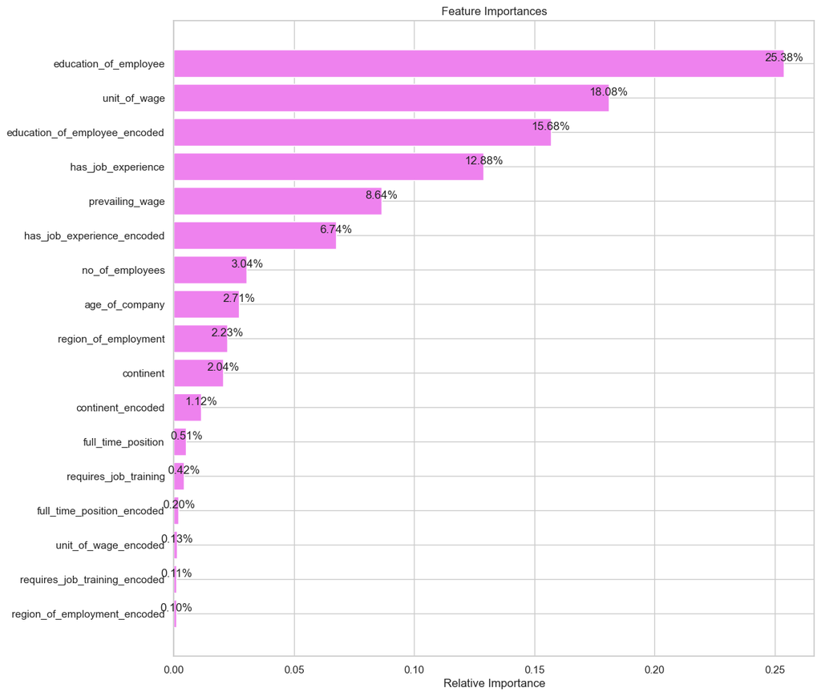

```python
# Define the feature names
feature_names = X_train.columns

# Collect the feature importances from different models
importances = []
models = [dtree_tuned, dtree_tuned, bagging_tuned, rf_tuned, abc_tuned, gbc_tuned, xgb_tuned, stacking_estimator.final_estimator]
for model in models:
    if hasattr(model, 'feature_importances_'):
        importances.append(model.feature_importances_)

# Calculate the mean feature importances if at least one model has feature importances
if importances:
    importances = np.mean(importances, axis=0)

    # Sort feature importances in ascending order
    indices = np.argsort(importances)

    # Plot the feature importances in ascending order
    plt.figure(figsize=(12, 12))
    plt.title('Feature Importances')
    bar_plot = plt.barh(range(len(indices)), importances[indices], color='violet', align='center')
    plt.yticks(range(len(indices)), [feature_names[i] for i in indices])

    # Add percentage labels on each bar
    for i in range(len(indices)):
        plt.text(importances[indices][i], i, f'{importances[indices][i]*100:.2f}%', ha='center', va='bottom')

    plt.xlabel('Relative Importance')
    plt.show()
```

- Important features of the final model in determining visa approval or not indicate that education_of_employee has relative importance of 25.38%, unit_of_wage , 18.08% of relative importance, and the least factor is whether an employee require job training or not.
- Other factors are indicated in the above plot in the order of their importance in determining whether an employee would be granted visa or not.

**Important features of the final model**

## Actionable Insights and Recommendations

**Actionable Insights** * The factors that ultimately decide visa status of an employee in the decreasing order of their importance are Education level or qualification of an employee(25.38% relative importance), unit of wages( 18.08% relative importance), job esperience(12.88% relative importance), prevailing wage(8.64%), number of employees and age of company ( both have ~3% relative importance), while region of employment and continent have ~2% relative importance each. * The wage level associated with the job is an influential factor in the visa approval process. Higher wages may indicate higher-skilled positions with potentially better chances of approval. * Prevailing wage holds a significant influence on visa approval decisions, accounting for 8.64% relative importance in the model. This factor signifies the importance of offering competitive wages in alignment with industry standards for visa approval. * The number of employees within the company plays a notable role in the visa approval process, accounting for about 3% relative importance. This factor may reflect the organization's stability, growth potential, and its capacity to support additional employment. * Highlight the company's growth trajectory and its ability to create employment opportunities when submitting visa applications. Emphasize the positive impact of hiring additional employees on the local economy and workforce. * The age of the company is a contributing factor with around 3% relative importance in visa approval decisions. The longevity and establishment of the company may signal reliability, experience, and commitment to long-term operations. * Other factors like full time position, and requires job training have less than 1% relative importance each. **Recommendation:** * Data Transparency and Documentation:Ensure that all visa applications include clear and comprehensive documentation related to the education level and qualifications of the employees. Highlight the relevance of their educational background to the job roles they are applying for. * Focus on Competitive Compensation:Emphasize the importance of competitive wages aligned with industry standards to enhance the chances of visa approval. Providing attractive remuneration packages can support visa applications for skilled workers. * Training and Skill Development Programs:While job training may have a lower relative importance in the final model, investing in training and skill development programs for employees can enhance their overall competency and performance. Strengthening employees' skills can have a positive impact on visa approval and job success. * Continuous Monitoring and Adjustment:Regularly monitor and analyze the factors influencing visa approval to adapt strategies accordingly. Stay informed about regulatory changes, visa requirements, and market trends to optimize the visa application process. * Leverage Insights for Strategic Decision-making:Utilize the actionable insights derived from the model's important features to inform strategic decision-making related to visa approvals. Tailoring visa applications based on the highlighted factors can increase the likelihood of successful approvals. * While full-time positions may not heavily impact visa approval, ensure that job roles and positions align with regulatory requirements and are clearly articulated within visa applications. Highlight the stability and commitment of full-time roles for sustainable employment. * Consider conducting a temporal analysis to assess how visa approval trends have evolved over time. Analyze historical data to identify patterns, changes in approval criteria, and regulatory updates that may impact visa application outcomes. * Implement a feedback loop mechanism to gather insights from rejected visa applications and incorporate the feedback into the model training process. Utilize rejected application data to identify common reasons for denial and refine the model accorfingly. * Conduct a more detailed examination of the relative importance of each feature in the model to identify additional key determinants of visa approval. This analysis can provide deeper insights into the impact of various factors on the decision-making process. * The final model can further be fine tuned. Adjusting hyperparameters can lead to improved model robustness and efficiecy. * By incorporating these actionable insights and recommendations, organizations can improve their visa approval rates, enhance employee retention, and align with regulations effectively when facilitating international workfore .